# Juvenile snowshoe hare weight: exploratory report

Teague Tran

11/18/2020

### a) Introduction

Snowshoe hares (*Lepus americanus*) are keystone species in northern boreal forests that have population fluctuations of 8-11 years. Before the study, [*Snowshoe hare physical data in Bonanza Creek Experimental Forest: 1999-Present*](https://portal.edirepository.org/nis/mapbrowse?packageid=knb-lter-bnz.55.22) (Kielland et al. 2017), comparisons of snowshoe hare populations were solely qualitative. This report uses the data from Kielland et al. and provides an exploratory overview of differences in juvenile snowshoe hare weight observed in a mark-recapture study in Bonanza Creek, AK, from 1999 to 2012. (Kielland et al. 2017). The juvenile count per year, effect of sex and site location on weight, the effect of sex on weight, and the relationship between hindfoot length and weight are all analyzed in this report.

### b) Data and analyses:

In this study, data from [*Snowshoe hare physical data in Bonanza Creek Experimental Forest: 1999-Present*](https://portal.edirepository.org/nis/mapbrowse?packageid=knb-lter-bnz.55.22) (Kielland et al. 2017) was used to analyze and visualize certain attributes of juvenile snowshoe hare population in Bonanza Creek, Alaska. The data contains observations for 3,197 observations for each snowshoe hare trapped in the mark and recapture study over a 14 year period (1999-2012). All samples were captured at a total of three environment types (will be called site): Black Spruce assemblages, diverse mature assemblages, and riparian areas. Data visualization consisted of histograms comparing juvenile capture rate per year, box/beeswarm plots to see the effects of sex and site, tables to see the effect of sex on weight, and scatterplots to visualize the relationship between hindfoot length and weight. Mean weight based on sex was analyzed using two-sample t-tests, using a significance level of (α) of .05 throughout, with differences between groups described by Cohen’s d effect size. An ANOVA was also performed to analyze the effect of site on weight. Finally, the relationship of juvenile hindfoot length and body weight was analyzed through linear regression and correlation.

### c) Exploratory findings:

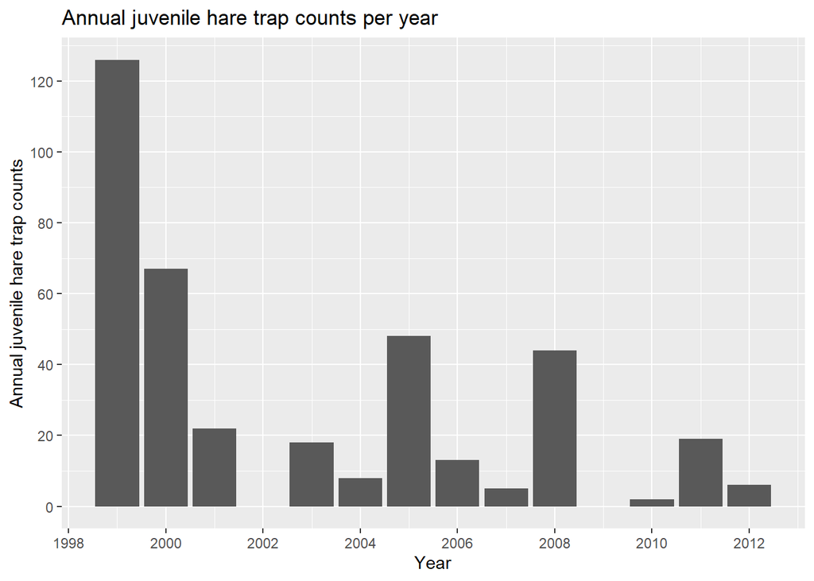

**Figure 1.** Number of annual juvenile snowshoe hare trapped around Bonanza Creek, Alaska is shown. The maximum count of hares was in 1999, where 126 was caught; while the minimum count was 2, in 2010. However, mean count was 31.5 and median count was 18.5. Total snowhare count is decreasing across time but this can be due to study effort (e.g. number of days and traps). Number and times of trappings should be uniform to make the data more consistent. Data: Kielland et al. 2017.

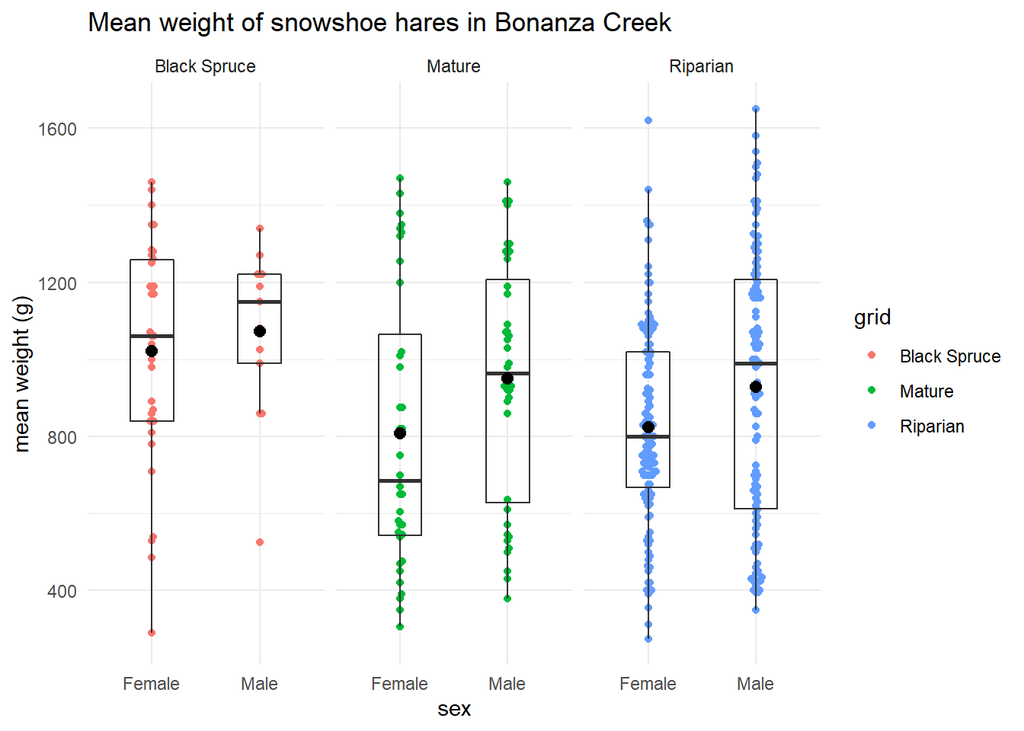

**Figure 2.** Mean weight of male and female snowshoe hares at the three various sites are shown. Red (Black Spruce), green (mature) and blue (riparian) points indicate individual observations for hare weight (g) of either sex. Box endpoints indicate teh 25<sup>th</sup> and 75<sup>th</sup> percentile values; the black line and black point within the box indicate the median and mean value for each sex at that site, respectively. Data: Kielland et al.2017.

Additional Analysis: Mean weight of snowshoe hares are similar along each site, except when comparing Black Spruce areas to Riparian areas (TukeyHSD; p = 0.0017256). Further analysis (two-way anova) needs to be performed to determine if there is interaction between site and sex on mean snowshoe hare size.

**Table 1**. t-tests on the data show that the mean weights between female and male (855.39 $\pm$ 292.25 and 945.86 $\pm$ 333.22 g respectively; mean $\pm$ 1 standard deviation ) are significantly different (Welch’s two-sample ttest t(325) = 2.71; p = .00709). However, the effect size is considered “small” (Cohen’s *d* = -0.2904). This means that although the actual difference in mean weight (~90.5 g; 10.5% difference) is significantly different between juvenile female and male snowshoe hares, that difference is still considered small. Data: Kielland et al. 2017.

| Sex | Mean Weight (g) | Standard deviation (g) | Sample size |
| --- | --- | --- | --- |
| Female | 855.39 | 292.25 | 200 |
| Male | 945.86 | 333.22 | 163 |

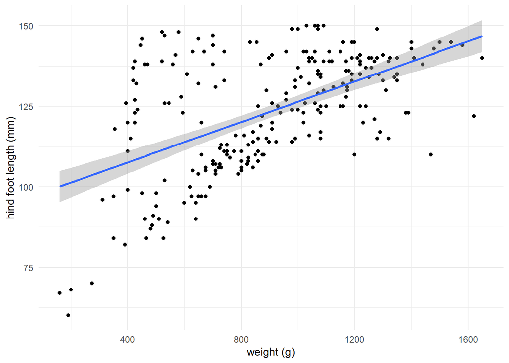

**Figure 3.** Relationship between hindfoot length (mm) and weight (g) for juvenile snowshoe hares. Each point indicates a single hare observation. Linear model summary: $\beta$<sub>1</sub> = .03 mm g<sup>-1</sup>, p < .001, R<sup>2</sup> = 0.3, Pearson’s *r* = .55). Data: Kielland et al.2017.

### d) Summary

Additional Analysis: Mean weight of snowshoe hares are similar along each site, except when comparing Black Spruce areas to Riparian areas (p = 0.0017256). Male and female weight are also significantly different (p = 0.007093). However, further analysis (two-way ANOVA) needs to be performed to determine if there is interaction between site and sex on mean snowshoe hare size.

Exploratory data analysis reveals the following initial findings:

- 1999 had the highest number of trapped juvenile snowshoe hares, where 126 hares were caught; the lowest was in 2010, with 2 caught.
- There is a significant difference in mean weight of juvenile snowshoe hares when comparing Black Spruce sites to Riparian sites.
- Male and female juvenile snowshoe hare weights are significantly different. However, the effect size is small.
- There is a moderately positive correlation between hindfoot length and weight

Next steps:

- Perform a two-way ANOVA for the effect of sex and site on juvenile snowshoe hare weight.
- Analyze the mean hindfoot length at each site type (ANOVA)

### e) Citations

Kielland, K., F.S. Chapin, R.W. Ruess, and Bonanza Creek LTER. 2017. Snowshoe hare physical data in Bonanza Creek Experimental Forest: 1999-Present ver 22. Environmental Data Initiative. https://doi.org/10.6073/pasta/03dce4856d79b91557d8e6ce2cbcdc14 (Accessed 2020-11-20).